# Lab1

Task # 1

```python
import pandas as pd

data = pd.read_csv('/content/q1data.csv')
data
```

|  | income | life_exp | population | year | country | four_regions | six_regions | eight_regions | world_bank_region |
| --- | --- | --- | --- | --- | --- | --- | --- | --- | --- |
| 0 | 1910.0 | 61.0 | 29200000.0 | 2010 | Afghanistan | asia | south_asia | asia_west | South Asia |
| 1 | 11100.0 | 78.1 | 2950000.0 | 2010 | Albania | europe | europe_central_asia | europe_east | Europe & Central Asia |
| 2 | 11100.0 | 74.7 | 36000000.0 | 2010 | Algeria | africa | middle_east_north_africa | africa_north | Middle East & North Africa |
| 3 | 46900.0 | 81.9 | 84500.0 | 2010 | Andorra | europe | europe_central_asia | europe_west | Europe & Central Asia |
| 4 | 7680.0 | 60.8 | 23400000.0 | 2010 | Angola | africa | sub_saharan_africa | africa_sub_saharan | Sub-Saharan Africa |
| ... | ... | ... | ... | ... | ... | ... | ... | ... | ... |
| 192 | 20400.0 | 75.4 | 28400000.0 | 2010 | Venezuela | americas | america | america_south | Latin America & Caribbean |
| 193 | 5350.0 | 73.3 | 88000000.0 | 2010 | Vietnam | asia | east_asia_pacific | east_asia_pacific | East Asia & Pacific |
| 194 | 4700.0 | 67.8 | 23200000.0 | 2010 | Yemen | asia | middle_east_north_africa | asia_west | Middle East & North Africa |
| 195 | 3200.0 | 57.5 | 13600000.0 | 2010 | Zambia | africa | sub_saharan_africa | africa_sub_saharan | Sub-Saharan Africa |
| 196 | 2560.0 | 54.4 | 12700000.0 | 2010 | Zimbabwe | africa | sub_saharan_africa | africa_sub_saharan | Sub-Saharan Africa |

197 rows × 9 columns

Based on the graph & data set provided, we can determine that the x axis/variable is income, and the y axis/variable is life_exp. The only other possible variabe that can be used to change the size in the bubble chart is. population.

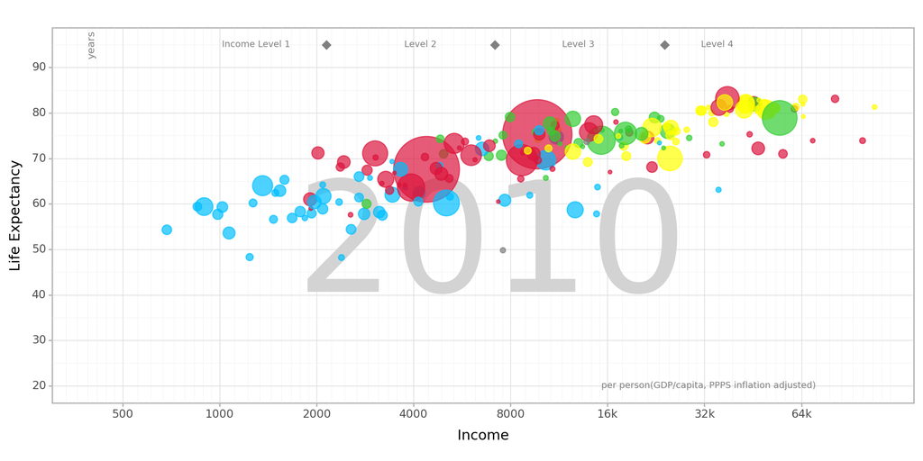

```
<Figure Size: (1000 x 500)>
```

```python
from plotnine import (ggplot, aes, geom_point, scale_x_log10, theme_light, ggtitle, xlab, ylab,
                      scale_fill_manual, guide_legend, annotate, scale_y_continuous,
                      scale_size_continuous, scale_color_manual, element_text, element_rect, theme, scale_x_continuous)

plot = (
    ggplot(data, aes(x='income', y='life_exp', size='population', color='four_regions'))
    + annotate('text', x=7000, y=50, label="2010", size=120, color='lightgray')
    + annotate('text', x=400, y=95, label="years", size=8, color='gray', angle=90)
    + annotate('text', x=33000, y=20, label="per person(GDP/capita, PPPS inflation adjusted)", color='gray', size=7)
    + annotate('text', x=1300, y=95, label="Income Level 1", color='gray', size=7)
    + annotate('text', x=4200, y=95, label="Level 2", color="gray", size=7)
    + annotate('text', x=13000, y=95, label="Level 3", color="gray", size=7)
    + annotate('text', x=35000, y=95, label="Level 4", color="gray", size=7)
    + annotate('text', x=[2150, 7150, 24150], y=[95] * 3, label='\u25C6', size=10, color='gray') # ChatGPT assisted with symbol
    + scale_x_log10(breaks=(500, 1000, 2000, 4000, 8000, 16000, 32000, 64000), labels=lambda x: ['500', '1000', '2000', '4000', '8000', '16k', '32k', '64k'])
    + scale_y_continuous(breaks=[20, 30, 40, 50, 60, 70, 80, 90], limits=(20, 95))
    + scale_size_continuous(range=(1, 30), guide=False) # assisted by ChatGPT to remove legend
    + geom_point(alpha=0.7)
    + theme_light()
    + theme(figure_size=(10, 5))
    + xlab("Income")
    + ylab("Life Expectancy")
    + scale_color_manual(
        breaks=('asia', 'europe', 'africa', 'americas'),
        values=('crimson', 'yellow', 'deepskyblue', 'limegreen'),
        guide= False)
)

plot
```

Based on this output, we can consider using geom_path which connects the points showing trends. After additional review, this would not be the best geometry since order of the data does not matter.

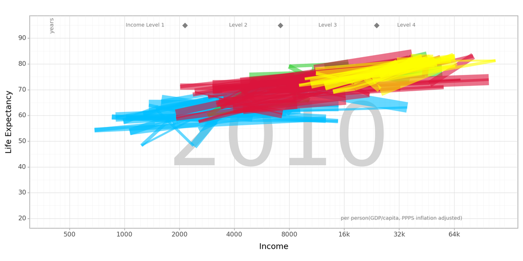

```
<Figure Size: (1000 x 500)>
```

```python
from plotnine import geom_path

plot = (
    ggplot(data, aes(x='income', y='life_exp', size='population', color='four_regions'))
    + annotate('text', x=7000, y=50, label="2010", size=120, color='lightgray')
    + annotate('text', x=400, y=95, label="years", size=8, color='gray', angle=90)
    + annotate('text', x=33000, y=20, label="per person(GDP/capita, PPPS inflation adjusted)", color='gray', size=7)
    + annotate('text', x=1300, y=95, label="Income Level 1", color='gray', size=7)
    + annotate('text', x=4200, y=95, label="Level 2", color="gray", size=7)
    + annotate('text', x=13000, y=95, label="Level 3", color="gray", size=7)
    + annotate('text', x=35000, y=95, label="Level 4", color="gray", size=7)
    + annotate('text', x=[2150, 7150, 24150], y=[95] * 3, label='\u25C6', size=10, color='gray')
    + scale_x_log10(breaks=(500, 1000, 2000, 4000, 8000, 16000, 32000, 64000), labels=lambda x: ['500', '1000', '2000', '4000', '8000', '16k', '32k', '64k'])
    + scale_y_continuous(breaks=[20, 30, 40, 50, 60, 70, 80, 90], limits=(20, 95))
    + scale_size_continuous(range=(1, 30), guide=False)
    + geom_path(alpha = 0.6)
    + theme_light()
    + theme(figure_size=(10, 5))
    + xlab("Income")
    + ylab("Life Expectancy")
    + scale_color_manual(
        breaks=('asia', 'europe', 'africa', 'americas'),
        values=('crimson', 'yellow', 'deepskyblue', 'limegreen'),
        guide= False)
)

plot
```

Task # 2

```python
data = pd.read_csv('/content/q2data.csv')
data
```

|  | imports | exports | energy | year | country | four_regions | six_regions | eight_regions | world_bank_region |
| --- | --- | --- | --- | --- | --- | --- | --- | --- | --- |
| 0 | NaN | NaN | NaN | 1997 | Afghanistan | asia | south_asia | asia_west | South Asia |
| 1 | 36.7 | 11.5 | 427 | 1997 | Albania | europe | europe_central_asia | europe_east | Europe & Central Asia |
| 2 | 22.5 | 22.6 | 825 | 1997 | Algeria | africa | middle_east_north_africa | africa_north | Middle East & North Africa |
| 3 | NaN | NaN | NaN | 1997 | American Samoa | NaN | NaN | NaN | NaN |
| 4 | NaN | NaN | 434 | 1997 | Angola | africa | sub_saharan_africa | africa_sub_saharan | Sub-Saharan Africa |
| ... | ... | ... | ... | ... | ... | ... | ... | ... | ... |
| 201 | 52.2 | 44.8 | 340 | 1997 | Vietnam | asia | east_asia_pacific | east_asia_pacific | East Asia & Pacific |
| 202 | NaN | NaN | NaN | 1997 | Virgin Islands (U.S.) | NaN | NaN | NaN | NaN |
| 203 | NaN | NaN | 241 | 1997 | Yemen | NaN | NaN | NaN | NaN |
| 204 | 31.6 | 24.6 | 617 | 1997 | Zambia | africa | sub_saharan_africa | africa_sub_saharan | Sub-Saharan Africa |
| 205 | 45.1 | 43.4 | 845 | 1997 | Zimbabwe | africa | sub_saharan_africa | africa_sub_saharan | Sub-Saharan Africa |

206 rows × 9 columns

```python
from plotnine import xlim, ylim, scale_size, scale_x_discrete, scale_y_discrete, element_line, scale_size_discrete, scale_size_area
```

Based on the graph & data set provided, we can determine that the x axis/variable is exports, and the y axis/variable is imports. The only other possible variabe that can be used to change the size in the bubble chart is. energy. We are still using four_regions and colors as the differentiator.

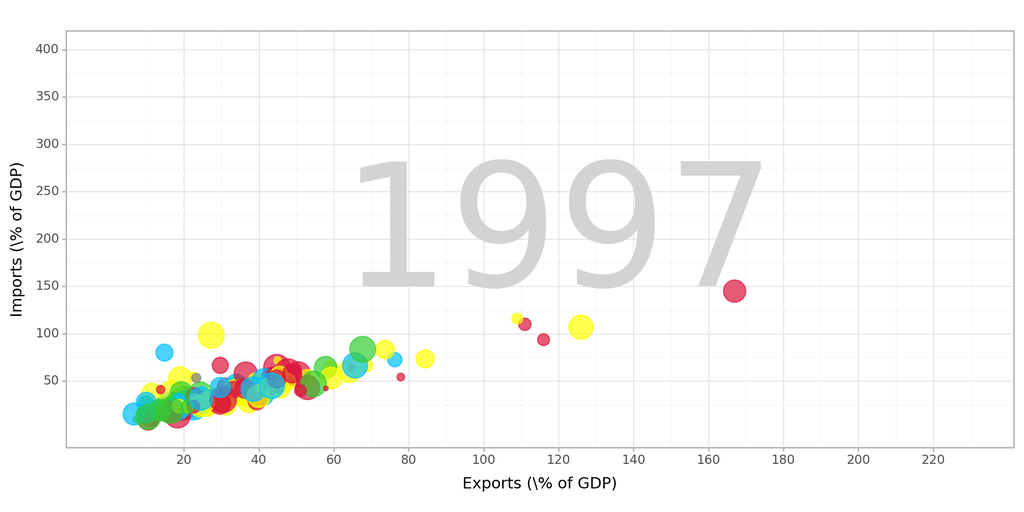

```
<Figure Size: (1000 x 500)>
```

```python
from plotnine.scales.scale_xy import scale_y_log10
from plotnine.scales.scale_size import scale_size_discrete

plot = (
    ggplot(data, aes(x='exports', y='imports', size='energy', color='four_regions'))
    + annotate('text', x=120, y=200, label="1997", size=120, color='lightgray')
    + annotate('text', x=400, y=95, label="years", size=8, color='gray', angle=90)
    + annotate('text', x=33000, y=20, label="per person(GDP/capita, PPPS inflation adjusted)", color='gray', size=7)
    + scale_x_continuous(breaks=(20, 40, 60, 80, 100, 120, 140, 160, 180, 200, 220), limits = (0, 230))
    + scale_y_continuous(breaks=[50, 100, 150, 200, 250, 300, 350, 400], limits=(0, 400))
    + scale_size_discrete(range=(.5, 10), guide=False)
    + geom_point(alpha=0.7)
    + theme_light()
    + theme(figure_size=(10, 5))
    + xlab("Exports (\% of GDP)")
    + ylab("Imports (\% of GDP)")
    + scale_color_manual(
        breaks=('asia', 'europe', 'africa', 'americas'),
        values=('crimson', 'yellow', 'deepskyblue', 'limegreen'),
        guide= False)
)

plot
```

Based on this visualization, we could consider using geom_jitter since many of the points overlap and are a little hard to interpret. The tradeoff here is that although we can see the datapoints better, we can no longer solely rely on the visualizaiton since it no longer accurately represents the data.

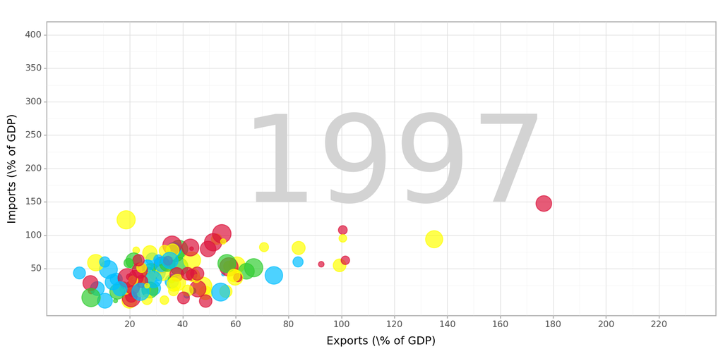

```
<Figure Size: (1000 x 500)>
```

```python
from plotnine import geom_jitter

plot = (
    ggplot(data, aes(x='exports', y='imports', size='energy', color='four_regions'))
    + annotate('text', x=120, y=200, label="1997", size=120, color='lightgray')
    + annotate('text', x=400, y=95, label="years", size=8, color='gray', angle=90)
    + annotate('text', x=33000, y=20, label="per person(GDP/capita, PPPS inflation adjusted)", color='gray', size=7)
    + scale_x_continuous(breaks=(20, 40, 60, 80, 100, 120, 140, 160, 180, 200, 220), limits = (0, 230))
    + scale_y_continuous(breaks=[50, 100, 150, 200, 250, 300, 350, 400], limits=(0, 400))
    + scale_size_discrete(range=(1, 10), guide=False)
    + geom_jitter(alpha=0.7, width=15, height=40)
    + theme_light()
    + theme(figure_size=(10, 5))
    + xlab("Exports (\% of GDP)")
    + ylab("Imports (\% of GDP)")
    + scale_color_manual(
        breaks=('asia', 'europe', 'africa', 'americas'),
        values=('crimson', 'yellow', 'deepskyblue', 'limegreen'),
        guide= False)
)

plot
```

Task # 3

```python
data = pd.read_csv('/content/q3data.csv')
data
```

|  | internet_users | gdp | income | year | country | four_regions | six_regions | eight_regions | world_bank_region |
| --- | --- | --- | --- | --- | --- | --- | --- | --- | --- |
| 0 | 0.00456 | 330.0 | 1190.0 | 2001 | Afghanistan | asia | south_asia | asia_west | South Asia |
| 1 | 0.39000 | 2570.0 | 6780.0 | 2001 | Albania | europe | europe_central_asia | europe_east | Europe & Central Asia |
| 2 | 1.59000 | 3770.0 | 9230.0 | 2001 | Algeria | africa | middle_east_north_africa | africa_north | Middle East & North Africa |
| 3 | NaN | 10500.0 | NaN | 2001 | American Samoa | NaN | NaN | NaN | NaN |
| 4 | 11.30000 | 42600.0 | 35600.0 | 2001 | Andorra | europe | europe_central_asia | europe_west | Europe & Central Asia |
| ... | ... | ... | ... | ... | ... | ... | ... | ... | ... |
| 210 | 1.85000 | 847.0 | 3270.0 | 2001 | Vietnam | asia | east_asia_pacific | east_asia_pacific | East Asia & Pacific |
| 211 | 27.50000 | 36700.0 | NaN | 2001 | Virgin Islands (U.S.) | NaN | NaN | NaN | NaN |
| 212 | 0.51900 | 1190.0 | 4940.0 | 2001 | Yemen | asia | middle_east_north_africa | asia_west | Middle East & North Africa |
| 213 | 0.47800 | 991.0 | 2080.0 | 2001 | Zambia | africa | sub_saharan_africa | africa_sub_saharan | Sub-Saharan Africa |
| 214 | 1.10000 | 1330.0 | 3190.0 | 2001 | Zimbabwe | africa | sub_saharan_africa | africa_sub_saharan | Sub-Saharan Africa |

215 rows × 9 columns

Based on the graph & data set provided, we can determine that the x axis/variable is internet_users, and the y axis/variable is gdp. The only other possible variabe that can be used to change the size in the bubble chart is. income. We are still using four_regions and colors as the differentiator.

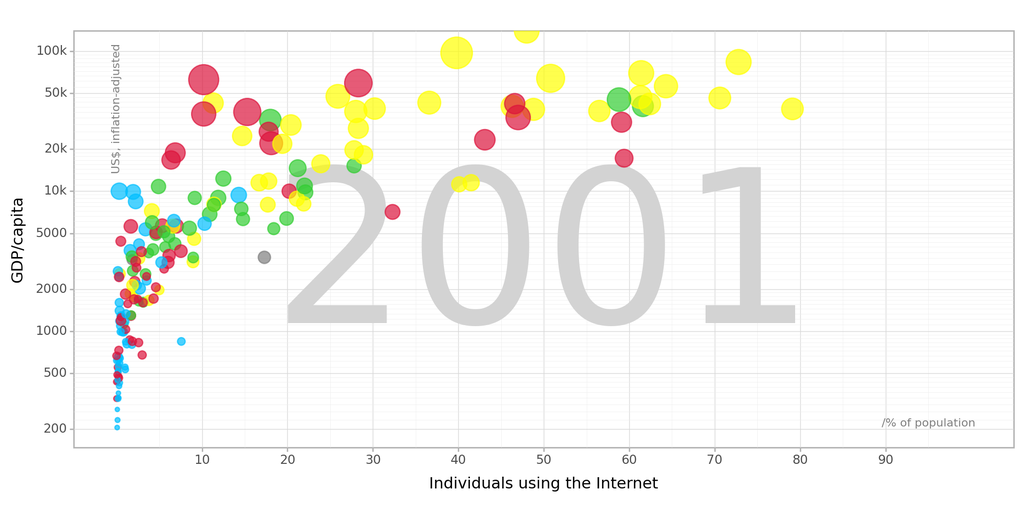

```
<Figure Size: (1000 x 500)>
```

```python
plot = (
    ggplot(data, aes(x='internet_users', y='gdp', size='income', color='four_regions'))
    + annotate('text', x=50, y=3000, label="2001", size=150, color='lightgray')
    + annotate('text', x=0, y=39000, label="US$, inflation-adjusted", size=8, color='gray', angle=90)
    + annotate('text', x=95, y=220, label="/% of population", color='gray', size=8)
    + scale_x_continuous(breaks=(10, 20, 30, 40, 50, 60, 70, 80, 90), limits = (0, 100))
    + scale_y_log10(breaks=[200, 500, 1000, 2000, 5000, 10000, 20000, 50000, 100000], labels=lambda y: ['200', '500', '1000', '2000', '5000', '10k', '20k', '50k', '100k'], limits=(0, 140000))
    + scale_size_continuous(range=(1, 12), guide=False)
    + geom_point(alpha=0.7)
    + theme_light()
    + theme(figure_size=(10, 5))
    + xlab("Individuals using the Internet")
    + ylab("GDP/capita")
    + scale_color_manual(
        breaks=('asia', 'europe', 'africa', 'americas'),
        values=('crimson', 'yellow', 'deepskyblue', 'limegreen'),
        guide= False)
)

plot
```

Based on this visualization, we could consider using a histogram or heatmap. the simple version below does provide another wayto look at the data, but does not help much.

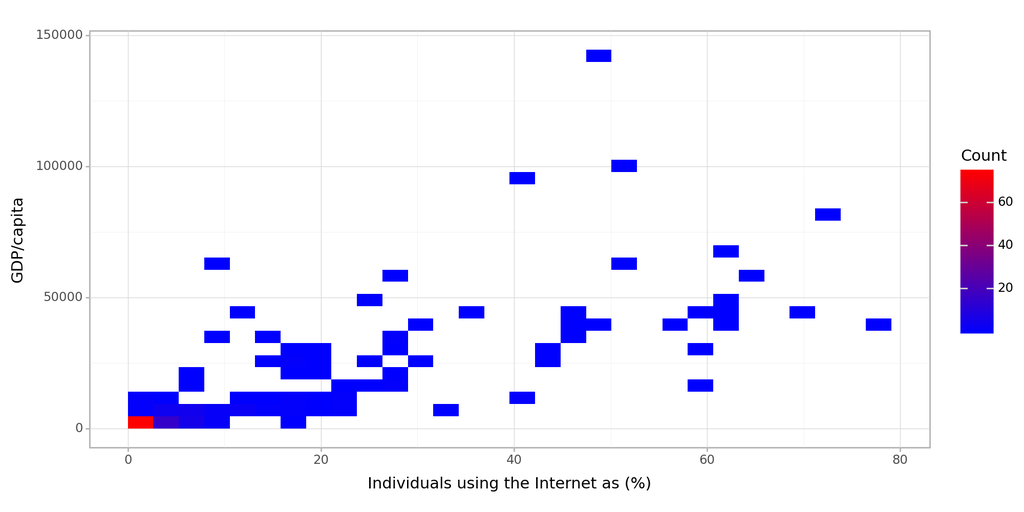

```
<Figure Size: (1000 x 500)>
```

```python
from plotnine import ggplot, aes, geom_bin2d, theme_light, xlab, ylab, scale_fill_gradient, theme

heatmap_plot = (
    ggplot(data, aes(x='internet_users', y='gdp'))
    + geom_bin2d(bins=30)
    + theme_light()
    + theme(figure_size=(10, 5))
    + xlab("Individuals using the Internet as (%)")
    + ylab("GDP/capita")
    + scale_fill_gradient(name="Count", low="blue", high="red")
)

heatmap_plot
```